# Data Analysis Skill Test

Adriano Ribeiro

7/5/2020

# Preparations

```r
library(dplyr)
library(ggplot2)
library(tidyr)
library(lubridate)
library(astsa)
library(forecast)
library(xts)
library(readxl)
```

# Case1

## Data

```r
data <- read.csv("TFP.csv")
str(data)
```

```
## 'data.frame':    186 obs. of  3 variables:
##  $ isocode: chr  "USA" "USA" "USA" "USA" ...
##  $ year   : int  1950 1951 1952 1953 1954 1955 1956 1957 1958 1959 ...
##  $ rtfpna : num  0.617 0.63 0.638 0.652 0.646 ...
```

```r
data$year <- ymd(data$year, truncated = 2)
```

## Analysis

### Exploratory Data Analysis

First, let’s check some statistics for each country.

```r
per_country <- data %>%
  as_tibble() %>%
  pivot_wider(names_from = isocode, values_from =rtfpna)
per_country %>% select(c(USA, MEX, CAN)) %>% summary()
```

```
##       USA              MEX              CAN
##  Min.   :0.6171   Min.   :0.7982   Min.   :0.8433
##  1st Qu.:0.7399   1st Qu.:1.0122   1st Qu.:0.9733
##  Median :0.7660   Median :1.0939   Median :1.0042
##  Mean   :0.8038   Mean   :1.1301   Mean   :0.9929
##  3rd Qu.:0.8805   3rd Qu.:1.2996   3rd Qu.:1.0295
##  Max.   :1.0204   Max.   :1.3837   Max.   :1.0661
```

Besides that, we could also look at some dispersion measure, such as the standard deviation. They are 0.116, 0.05, and 0.158 for the US, Canada and Mexico, respectively.

These statistics show that Mexico had the highest productivity, the biggest difference between maximum and minimum values, and the highest standard deviation. On the other hand, Canada had the smallest max-min difference and standard deviation between these 3 countries. Lastly, the US had the smallest mean throughout this period. To have a better understanding of the path took by the productivity in these three countries, let’s take a look at their graph.

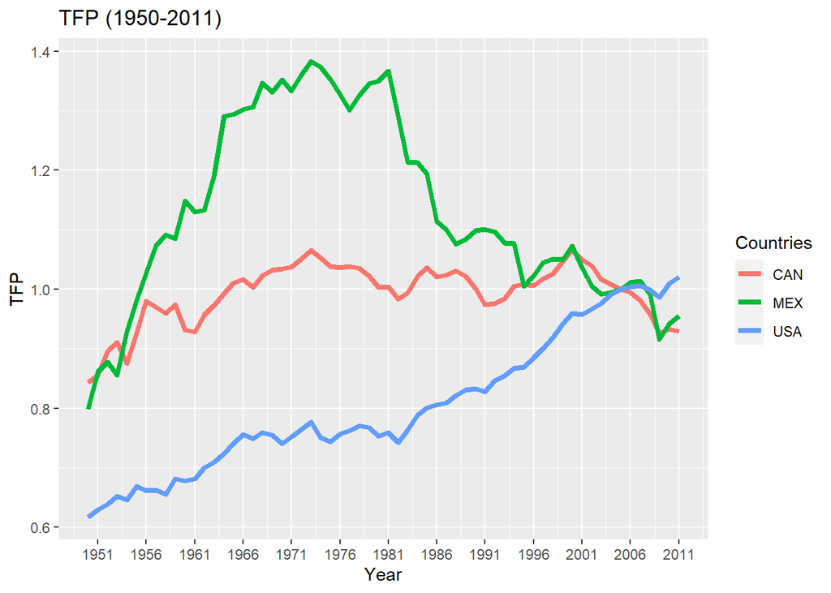

```r
ggplot(data, aes(x=year, y=rtfpna, col=isocode))+
  geom_line(size=1.5)+
  scale_x_date(breaks="5 years", date_labels=(format="%Y"))+
  labs(x="Year", y="TFP", title="TFP (1950-2011)", col="Countries")
```

From the plot, notice first that all three series are converging to the range between .9 and 1. Mexico’s TFP increased really fast in the 1950s and in the first half of the 1960s from .8 to 1.3, then it reached a plateau above 1.3 until 1981 to finally slump to the above mentioned range. Also, note that Mexico’s TFP had the hugest drop between 2008 and 2009, likely as a result of the Great Depression. Canada’s TFP, as the standard deviation showed, did not move much during this period, although it began as the biggest value in 1950, it was just slightly below .9, then it stabilized around 1 between 1965 and 2000 and fell a little afterwards, nevertheless still finishing the period above .9. Finally, the US’s TFP that was slightly above .6 in 1950, the minimum point between all these countries, steadily increased throughout the period to reach its maximum in 2011 above 1.

### Forecast

First of all, let’s transform the data in a time series object.

```r
data_ts <- ts(per_country[,-1], start=1950, end=2011, frequency=1)
```

The last graph tells us that we should treat each TFP separetely, that is, a model for each country.

**Mexico:** The serie becomes stationary after differencing twice.

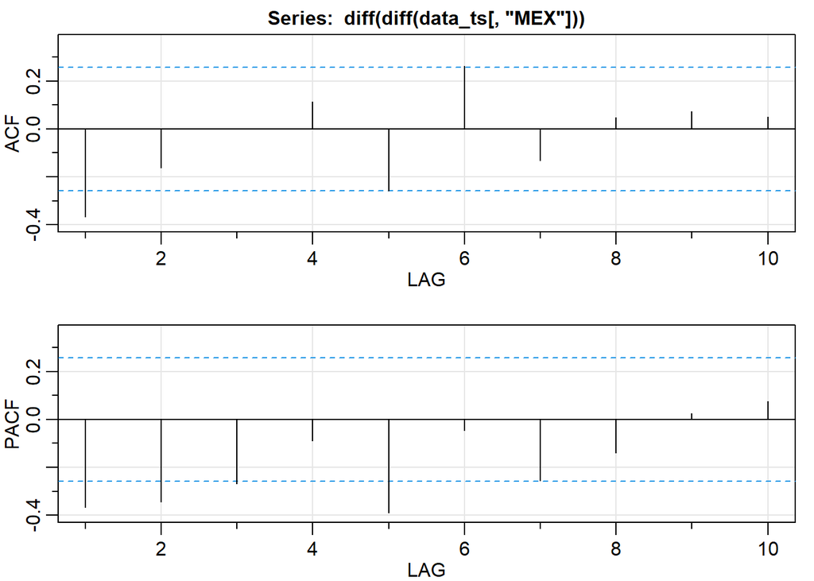

```
##       [,1]  [,2]  [,3]  [,4]  [,5]  [,6]  [,7]  [,8] [,9] [,10]
## ACF  -0.37 -0.16  0.00  0.11 -0.26  0.26 -0.13  0.05 0.07  0.05
## PACF -0.37 -0.34 -0.27 -0.09 -0.39 -0.05 -0.26 -0.14 0.02  0.08
```

```r
acf2(diff(diff(data_ts[,"MEX"])), max.lag = 10)
```

The autocorrelation and partial autocorrelation functions suggest the series could be an ARIMA(0,2,1), ARIMA(2,2,0) or ARIMA(2,2,1). The lowest AIC between these three options is given by the ARIMA(0,2,1) model.

For forecast purpose, we will compare the ARIMA model above against the ETS model in the last 10 years. To do that, let’s define a training set, then compare the forecast error of these two models.

```r
train_MEX <- subset(data_ts[,"MEX"], end=52)
ets_MEX <- ets(train_MEX)
fc_ets_MEX <- forecast(ets_MEX, h=10)
arima_MEX <- arima(train_MEX, order=c(0,2,1))
fc_arima_MEX <- forecast(arima_MEX, h=10)
accuracy(fc_ets_MEX, data_ts[,"MEX"])
```

```
##                        ME       RMSE        MAE        MPE     MAPE      MASE
## Training set -0.004639255 0.03266999 0.02523693 -0.4175821 2.219788 0.9110483
## Test set     -0.043871723 0.05230992 0.04387172 -4.5662975 4.566297 1.5837606
##                    ACF1 Theil's U
## Training set 0.06238307        NA
## Test set     0.51194672  1.922426
```

```r
accuracy(fc_arima_MEX, data_ts[,"MEX"])
```

```
##                        ME       RMSE        MAE        MPE     MAPE      MASE
## Training set -0.005401946 0.03393699 0.02729705 -0.4490029 2.391014 0.9854180
## Test set     -0.020989575 0.03142131 0.02481903 -2.2047011 2.582690 0.8959623
##                    ACF1 Theil's U
## Training set 0.03406867        NA
## Test set     0.34116392  1.121388
```

Looking at the RMSE, the ARIMA(0,2,1) model performs better than the ETS model on the Test Set. Therefore, here follows a 10 years forecast of the serie.

```r
forecast(arima(data_ts[,"MEX"], order=c(0,2,1)), h=10)
```

```
##      Point Forecast     Lo 80     Hi 80     Lo 95    Hi 95
## 2012      0.9494087 0.9059957 0.9928216 0.8830143 1.015803
## 2013      0.9430517 0.8768985 1.0092049 0.8418791 1.044224
## 2014      0.9366947 0.8497506 1.0236388 0.8037252 1.069664
## 2015      0.9303377 0.8230143 1.0376611 0.7662007 1.094475
## 2016      0.9239807 0.7961607 1.0518007 0.7284969 1.119465
## 2017      0.9176237 0.7689537 1.0662937 0.6902526 1.144995
## 2018      0.9112667 0.7412747 1.0812588 0.6512863 1.171247
## 2019      0.9049097 0.7130605 1.0967590 0.6115016 1.198318
## 2020      0.8985527 0.6842776 1.1128279 0.5708472 1.226258
## 2021      0.8921958 0.6549090 1.1294825 0.5292970 1.255095
```

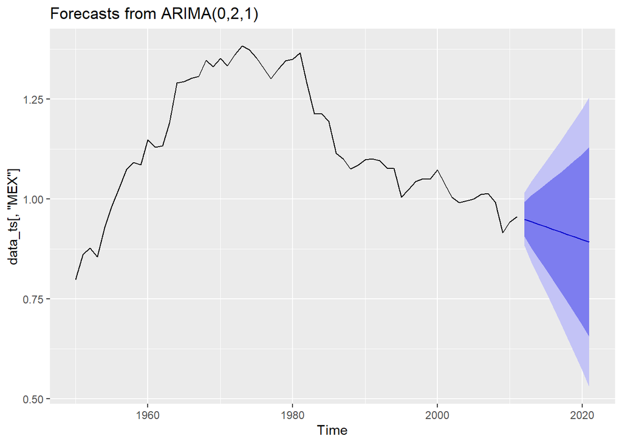

```r
autoplot(forecast(arima(data_ts[,"MEX"], order=c(0,2,1)), h=10))
```

**Canada:** Again, the TFP serie becomes stationary after differencing twice.

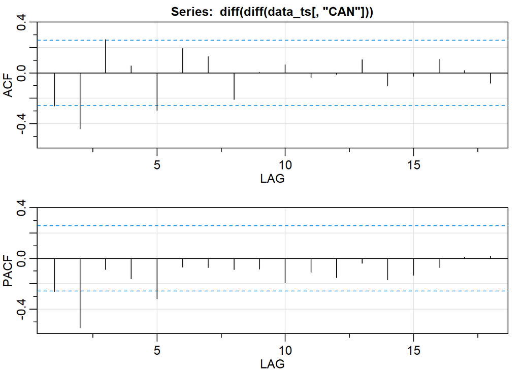

```
##       [,1]  [,2]  [,3]  [,4]  [,5]  [,6]  [,7]  [,8]  [,9] [,10] [,11] [,12]
## ACF  -0.26 -0.44  0.26  0.06 -0.29  0.19  0.13 -0.21  0.00  0.07 -0.04 -0.01
## PACF -0.26 -0.55 -0.09 -0.16 -0.32 -0.07 -0.07 -0.09 -0.08 -0.19 -0.11 -0.15
##      [,13] [,14] [,15] [,16] [,17] [,18]
## ACF   0.11 -0.10 -0.03  0.11  0.02 -0.08
## PACF -0.04 -0.17 -0.13 -0.07  0.01  0.02
```

```r
acf2(diff(diff(data_ts[,"CAN"])))
```

The autocorrelation and partial autocorrelation functions suggest the serie could follow an ARIMA(0,2,3) or ARIMA(2,2,3). The latter generates a smaller AIC than the first.

```r
train_CAN <- subset(data_ts[,"CAN"], end=52)
ets_CAN <- ets(train_CAN)
fc_ets_CAN <- forecast(ets_CAN, h=10)
arima_CAN <- arima(train_CAN, order=c(0,2,3))
fc_arima_CAN <- forecast(arima_CAN, h=10)
accuracy(fc_ets_CAN, data_ts[,"CAN"])
```

```
##                        ME       RMSE        MAE        MPE     MAPE     MASE
## Training set  0.003981085 0.01942576 0.01508497  0.4014974 1.539588 0.980823
## Test set     -0.071549638 0.08102255 0.07154964 -7.4727974 7.472797 4.652150
##                   ACF1 Theil's U
## Training set 0.1345404        NA
## Test set     0.7027684  5.299226
```

```r
accuracy(fc_arima_CAN, data_ts[,"CAN"])
```

```
##                        ME       RMSE        MAE        MPE     MAPE      MASE
## Training set -0.002632038 0.01771259 0.01319838 -0.2745386 1.344408 0.8581571
## Test set     -0.084149750 0.09637917 0.08414975 -8.7974318 8.797432 5.4714079
##                     ACF1 Theil's U
## Training set -0.01803423        NA
## Test set      0.69306939  6.311863
```

```r
forecast(ets(data_ts[,"CAN"]), h=10)
```

```
##      Point Forecast     Lo 80     Hi 80     Lo 95     Hi 95
## 2012      0.9294057 0.9047478 0.9540636 0.8916948 0.9671167
## 2013      0.9294057 0.8945360 0.9642755 0.8760770 0.9827344
## 2014      0.9294057 0.8866999 0.9721115 0.8640928 0.9947186
## 2015      0.9294057 0.8800937 0.9787177 0.8539895 1.0048220
## 2016      0.9294057 0.8742735 0.9845380 0.8450882 1.0137232
## 2017      0.9294057 0.8690116 0.9897999 0.8370408 1.0217706
## 2018      0.9294057 0.8641727 0.9946387 0.8296405 1.0291710
## 2019      0.9294057 0.8596688 0.9991426 0.8227524 1.0360590
## 2020      0.9294057 0.8554387 1.0033727 0.8162829 1.0425285
## 2021      0.9294057 0.8514377 1.0073737 0.8101639 1.0486475
```

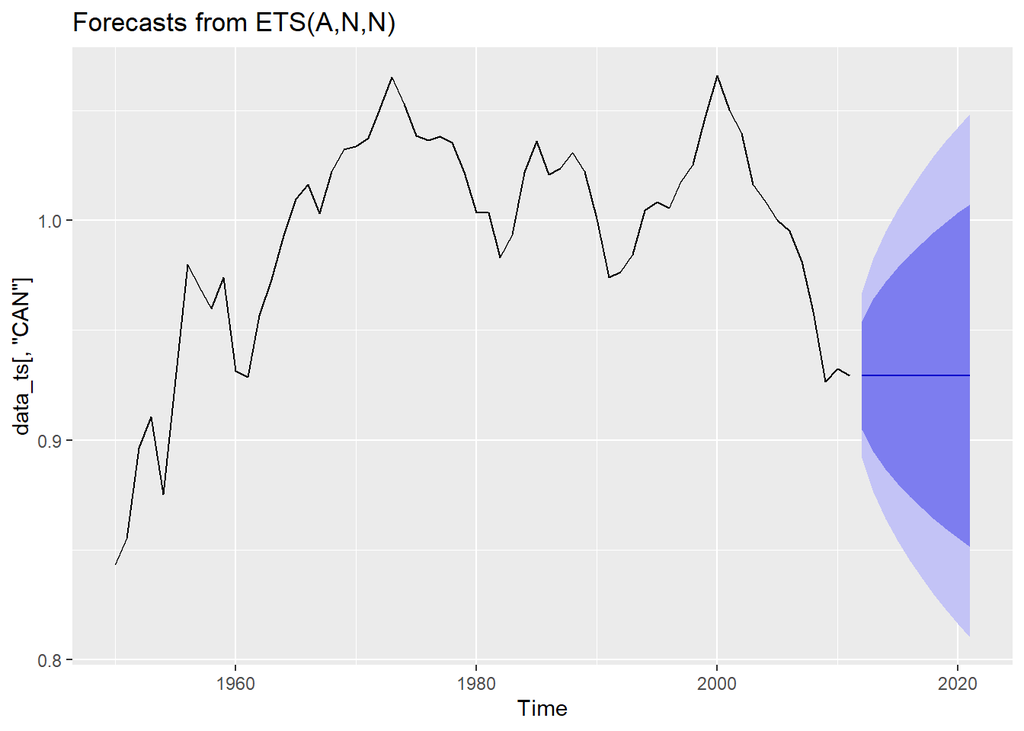

```r
autoplot(forecast(ets(data_ts[,"CAN"]), h=10))
```

Notice that ETS gives a constant as the forecast, this kind of estimate performed better than the ARIMA model (although not showed here, the ARIMA test previewed an upward trend when actual data decreased). There is space for an even improved model as a future work.

**US:**

For the US, the TFP data has an upward trend, thus first differencing was enough to stationarize it.

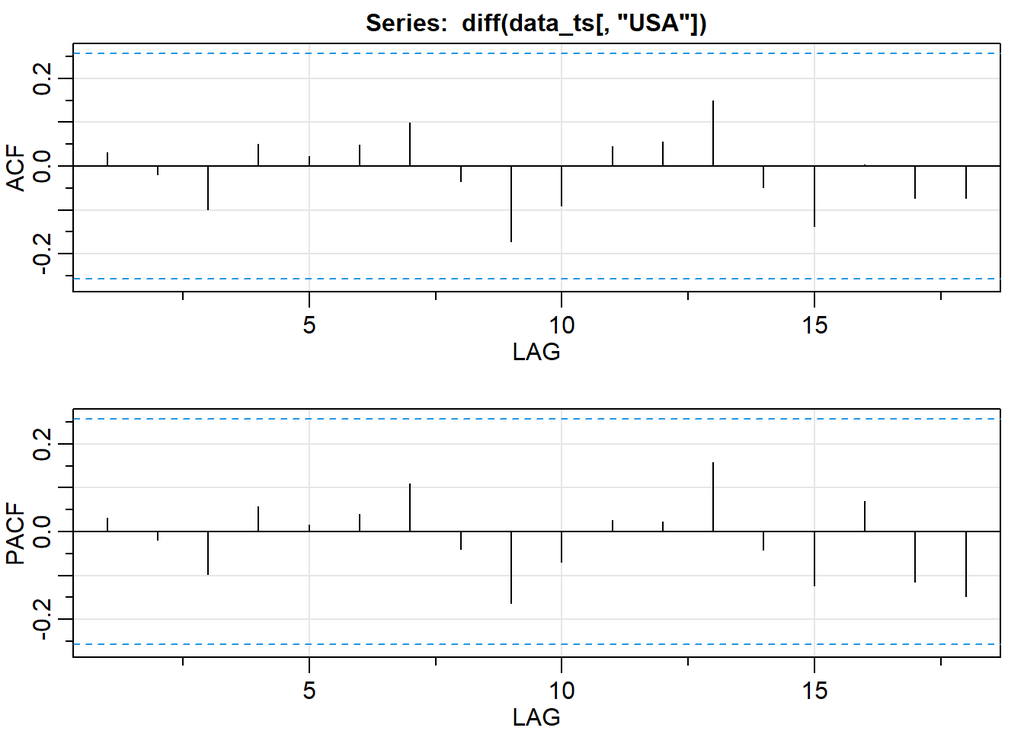

```
##      [,1]  [,2] [,3] [,4] [,5] [,6] [,7]  [,8]  [,9] [,10] [,11] [,12] [,13]
## ACF  0.03 -0.02 -0.1 0.05 0.02 0.05 0.10 -0.03 -0.17 -0.09  0.04  0.06  0.15
## PACF 0.03 -0.02 -0.1 0.06 0.02 0.04 0.11 -0.04 -0.16 -0.07  0.03  0.02  0.16
##      [,14] [,15] [,16] [,17] [,18]
## ACF  -0.05 -0.14  0.00 -0.07 -0.07
## PACF -0.04 -0.12  0.07 -0.11 -0.15
```

```r
acf2(diff(data_ts[,"USA"]))
```

The plot does not show any serial correlation after taking the first difference. The suggested model would then be an ARIMA(0,1,0), that is, just a constant with noise.

Next, I’ll compare, for the past 10 years of data, this model with two versions of ETS, one with additive trend and another with damped trend. The reason for doing that is to avoid an explosive plath to the TFP as given by the additive trend.

```r
train_US <- subset(data_ts[,"USA"], end=52)
ets_US <- ets(train_US)
fc_ets_US <- forecast(ets_US, h=10)
etsD_US <- ets(train_US, damped=TRUE)
fc_etsD_US <- forecast(etsD_US, h=10)
arima_US <- arima(train_US, order=c(0,1,0))
fc_arima_US <- forecast(arima_US, h=10)
accuracy(fc_ets_US, data_ts[,"USA"])
```

```
##                        ME       RMSE         MAE         MPE     MAPE      MASE
## Training set 3.650877e-06 0.01142166 0.009279298 -0.03034455 1.227872 0.8077203
## Test set     1.505807e-03 0.01197889 0.010154063  0.15087945 1.019207 0.8838645
##                    ACF1 Theil's U
## Training set 0.01700598        NA
## Test set     0.65027723  1.055756
```

```r
accuracy(fc_etsD_US, data_ts[,"USA"])
```

```
##                        ME       RMSE         MAE        MPE      MAPE      MASE
## Training set 0.0013942023 0.01170347 0.009747250 0.14438385 1.2842998 0.8484533
## Test set     0.0007770725 0.01153863 0.009567418 0.07739628 0.9603717 0.8327998
##                     ACF1 Theil's U
## Training set -0.01308576        NA
## Test set      0.63543753   1.01715
```

```r
accuracy(fc_arima_US, data_ts[,"USA"])
```

```
##                       ME       RMSE        MAE       MPE     MAPE      MASE
## Training set 0.006563357 0.01319893 0.01127920 0.8320939 1.475397 0.9818023
## Test set     0.038231868 0.04116095 0.03823187 3.8156200 3.815620 3.3279086
##                    ACF1 Theil's U
## Training set 0.01188357        NA
## Test set     0.41763625  3.611415
```

The RMSE criterion on the Test Set shows that the ETS model with damped trend performs better than the other two models.

```r
forecast(ets(data_ts[,"USA"], damped=TRUE), h=10)
```

```
##      Point Forecast     Lo 80    Hi 80     Lo 95    Hi 95
## 2012       1.025007 1.0048229 1.045191 0.9941381 1.055876
## 2013       1.029649 1.0008342 1.058465 0.9855803 1.073719
## 2014       1.034199 0.9983674 1.070031 0.9793993 1.088999
## 2015       1.038657 0.9966026 1.080712 0.9743401 1.102975
## 2016       1.043027 0.9952264 1.090827 0.9699223 1.116131
## 2017       1.047309 0.9940818 1.100536 0.9659052 1.128712
## 2018       1.051505 0.9930786 1.109932 0.9621495 1.140861
## 2019       1.055617 0.9921600 1.119075 0.9585677 1.152667
## 2020       1.059648 0.9912884 1.128007 0.9551013 1.164194
## 2021       1.063597 0.9904376 1.136757 0.9517093 1.175485
```

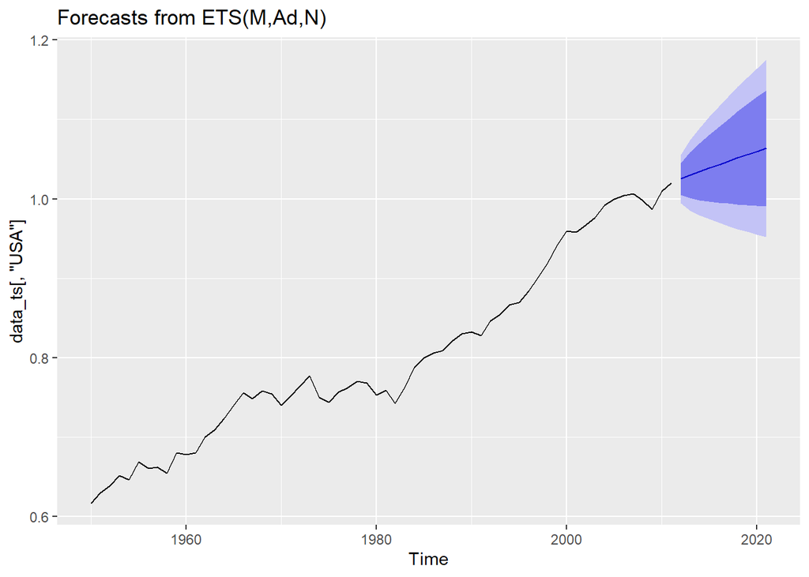

```r
autoplot(forecast(ets(data_ts[,"USA"], damped=TRUE), h=10))
```

### Other Features

A few variables could aid in explaining the TFP path. In order of importance:

*hc - Index of human capital per person, based on years of schooling (Barro and Lee 2013) and returns to education (Psacharopoulos 1994).*

*pop - Population (in millions):*

*emp - Number of persons engaged (in millions).*

Human capital could be related to productivity, since higher HC would be a key to innovations, therefore they would be positively correlated. Population and number of persons engaged (or number of people employed according to the PWT methodology) could also be positively related to TFP, once more people in a country or participating in the labor market could help in finding new ways to produce goods, in other words, a higher TFP or productivity.

# Case 2

## Data

```r
data2 <- read.csv("data_comexstat.csv")
str(data2)
```

```
## 'data.frame':    117965 obs. of  8 variables:
##  $ date   : chr  "1997-01-01" "1997-01-01" "1997-01-01" "1997-01-01" ...
##  $ product: chr  "corn" "corn" "corn" "corn" ...
##  $ state  : chr  "ES" "GO" "GO" "GO" ...
##  $ country: chr  "United States" "Argentina" "Bolivia" "United States" ...
##  $ type   : chr  "Import" "Import" "Export" "Export" ...
##  $ route  : chr  "Sea" "Ground" "Ground" "Sea" ...
##  $ tons   : num  44.05 54 0.2 3.49 27 ...
##  $ usd    : num  113029 36720 180 5688 18630 ...
```

```r
data2$date <- ymd(data2$date)
```

### Analysis

**Soybeans, Soybean Oil and Soybean Meal Exports:**

The first step to do is to separate the variables we are interested in.

```r
exports <- data2 %>% as_tibble() %>% filter(type=="Export")
products <- split(x=exports, f=exports$product)
```

To analyze monthly exports of soybeans, soybean oil and soybean meal, we could look at it either in tons or usd.

```r
soybeans <- products[["soybeans"]]
soybeans <- aggregate(soybeans[,c("tons","usd")], by=list(soybeans$date), FUN=sum)
soybeans$product <- "soybeans"

soybean_oil <- products[["soybean_oil"]]
soybean_oil <- aggregate(soybean_oil[,c("tons","usd")], by=list(soybean_oil$date), FUN=sum)
soybean_oil$product <- "soybean_oil"

soybean_meal <- products[["soybean_meal"]]
soybean_meal <- aggregate(soybean_meal[,c("tons","usd")], by=list(soybean_meal$date), FUN=sum)
soybean_meal$product <- "soybean_meal"

soy <- rbind(soybeans, soybean_oil, soybean_meal)
colnames(soy)[1] <- "date"
```

The data for tons and usd are, not surprisingly, very similar. Even if the exchange rate floats, the main component of exports trend should be the amount in tons. Below we plot the monthly data (in tons) for each of these products with their trend line. Bear in mind that if usd was used, the pattern would be the same.

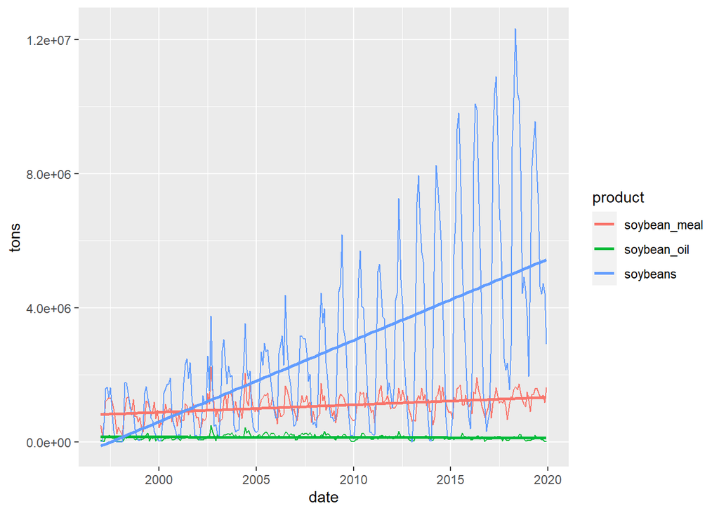

```r
ggplot(soy, aes(x=date, y=tons, col=product))+
  geom_line()+
  geom_smooth(se=F, method="lm")
```

From the plot, we notice that both soybean oil and soybean meal exports did not change much in the past 23 years. On the other hand, soybeans export, that was in a similar level of those two in 1997, increased abruptly. One interpretation is that Brazilian soybeans production grew really fast and was directed to exportation before any transformation. Notice also the similar seasonality of all three products, in which the exports spike in some months of the year, likely during the harvest. For a better understanding of the trend, it is better to look at the annual data.

```r
soy_tons_ts <- xts(x=cbind(soybeans=soybeans$tons, soybean_oil=soybean_oil$tons, soybean_meal=soybean_meal$tons), order.by=soybeans[,1], frequency=12)

soy_tons_yr <- do.call(rbind, lapply(split(soy_tons_ts, "years"), colSums))

soy_yr_df <- cbind.data.frame(year=seq(ymd("1997", truncated=2), ymd("2019", truncated = 2), by="years"), soy_tons_yr)
soy_yr_df$soybeans_yoy <- 100*(soy_yr_df$soybeans-lag(soy_yr_df$soybeans))/lag(soy_yr_df$soybeans)
soy_yr_df$soybean_oil_yoy <- 100*(soy_yr_df$soybean_oil-lag(soy_yr_df$soybean_oil))/lag(soy_yr_df$soybean_oil)
soy_yr_df$soybean_meal_yoy <- 100*(soy_yr_df$soybean_meal-lag(soy_yr_df$soybean_meal))/lag(soy_yr_df$soybean_meal)

tidy_soy_yr_df <- pivot_longer(data=soy_yr_df, cols=c(soybeans, soybean_oil, soybean_meal), names_to="type")
```

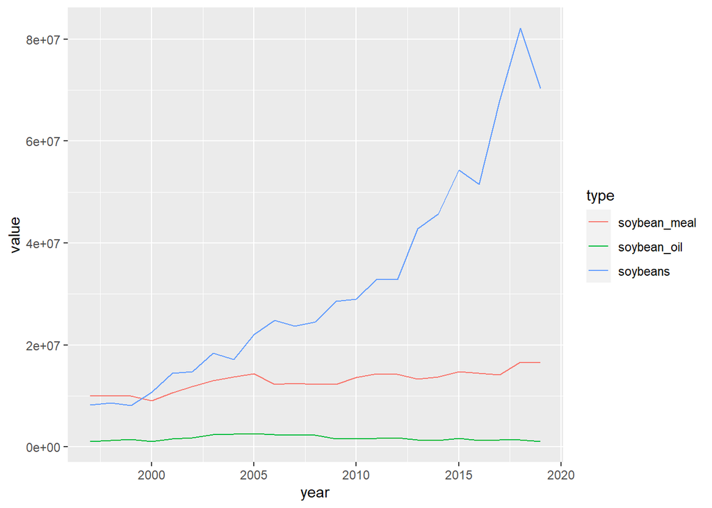

```r
ggplot(tidy_soy_yr_df, aes(x=year, y=value, col=type))+
  geom_line()
```

As we can see in the plot, in 2019 soybean oil was slightly below its level in 1997, reaching its peak in 2005. Soybean meal grew 66% in this period, contrasting the idea given by the trend in the monthly plot. Finally, soybeans exportation skyrocketed in this period, the total exports annual exports increased by 758%. We can take a better look at the growth rate for each year below, besides a few years with negative growth, the rates were positive during most of the period, reaching more than 35% in 2001.

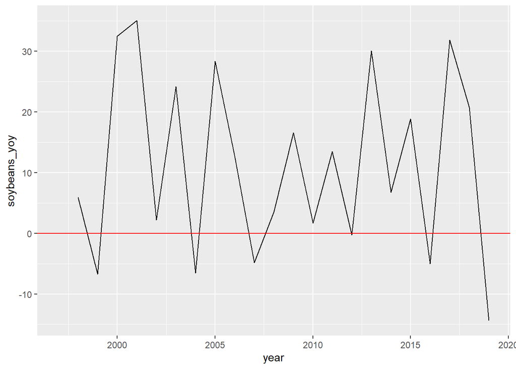

```r
ggplot(data=soy_yr_df, aes(x=year, y=soybeans_yoy))+
  geom_line()+
  geom_hline(yintercept = 0, col="red")
```

**The 3 Most Important Products Exported:**

For this, consider only the last 5 years. Let’s annualize the data for all goods.

```r
corn <- products[["corn"]]
corn <- aggregate(corn[,c("tons","usd")], by=list(corn$date), FUN=sum)
corn$product <- "corn"

sugar <- products[["sugar"]]
sugar <- aggregate(sugar[,c("tons","usd")], by=list(sugar$date), FUN=sum)
sugar$product <- "sugar"

wheat <- products[["wheat"]]
wheat <- aggregate(wheat[,c("tons","usd")], by=list(wheat$date), FUN=sum)
wheat$product <- "wheat"

products_tons_ts <- xts(x=cbind(soybeans=soybeans$tons, soybean_oil=soybean_oil$tons, soybean_meal=soybean_meal$tons, corn=corn$tons, sugar=sugar$tons), order.by=soybeans[,1], frequency=12)
products_tons_yr <- do.call(rbind, lapply(split(products_tons_ts, "years"), colSums))
products_tons_yr_df <- cbind.data.frame(year=seq(ymd("1997", truncated=2), ymd("2019", truncated = 2), by="years"), products_tons_yr)
wheat_tons_ts <- xts(x=wheat$tons, order.by = wheat[,1], frequency=12)
wheat_tons_yr <- do.call(rbind, lapply(split(wheat_tons_ts, "years"), colSums))
wheat_tons_yr <- c(rep(NA,6), wheat_tons_yr[1:4], NA, wheat_tons_yr[5:16])
products_tons_yr_df$wheat <- wheat_tons_yr
products_tons_yr_df <- as_tibble(products_tons_yr_df)
```

```r
products_tons_yr_df %>% filter(year(year)>=2015) %>% select(-year) %>% colSums()
```

```
##     soybeans  soybean_oil soybean_meal         corn        sugar        wheat
##    326331464      6711428     76647488    144599338    120033649      3885836
```

The table above informs the cumulative exports of each product in tons during the past 5 years. The three most important products are soybeans, corn and sugar. We could also check the exports in terms of USD to assess their importance.

```r
products_usd_ts <- xts(x=cbind(soybeans=soybeans$usd, soybean_oil=soybean_oil$usd, soybean_meal=soybean_meal$usd, corn=corn$usd, sugar=sugar$usd), order.by=soybeans[,1], frequency=12)
products_usd_yr <- do.call(rbind, lapply(split(products_usd_ts, "years"), colSums))
products_usd_yr_df <- cbind.data.frame(year=seq(ymd("1997", truncated=2), ymd("2019", truncated = 2), by="years"), products_usd_yr)
wheat_usd_ts <- xts(x=wheat$usd, order.by = wheat[,1], frequency=12)
wheat_usd_yr <- do.call(rbind, lapply(split(wheat_usd_ts, "years"), colSums))
wheat_usd_yr <- c(rep(NA,6), wheat_usd_yr[1:4], NA, wheat_usd_yr[5:16])
products_usd_yr_df$wheat <- wheat_usd_yr
products_usd_yr_df <- as_tibble(products_usd_yr_df)
```

```r
products_usd_yr_df %>% filter(year(year)>=2015) %>% select(-year) %>% colSums()
```

```
##     soybeans  soybean_oil soybean_meal         corn        sugar        wheat
## 123325529857   4795946873  28407723437  24447720910  40938486021    726945386
```

In terms of USD, in the past 5 years the three most important products are soybeans, sugar and soybean meal. Although having the second largest exports in tons, corn figures only as the 4th biggest export in USD.

**Importance of Routes:**

```r
table <- exports %>% filter(year(date)>=2015) %>% select(product, route) %>% table()
table
```

```
##               route
## product          Air Ground Other River   Sea
##   corn           384    485   460   293  6055
##   soybean_meal    29     69    35     1  5020
##   soybean_oil     22    945  1592    11  1979
##   soybeans       131    149   176   382  6337
##   sugar           78    920  2487    21 10108
##   wheat           18     48    69     0   233
```

In the last 5 years, Brazil has been exporting corn mainly by sea, in fact, it corresponds to 78.9% of the total number of transactions.

```r
round(100*table/rowSums(table), 1)
```

```
##               route
## product         Air Ground Other River  Sea
##   corn          5.0    6.3   6.0   3.8 78.9
##   soybean_meal  0.6    1.3   0.7   0.0 97.4
##   soybean_oil   0.5   20.8  35.0   0.2 43.5
##   soybeans      1.8    2.1   2.5   5.3 88.3
##   sugar         0.6    6.8  18.3   0.2 74.2
##   wheat         4.9   13.0  18.8   0.0 63.3
```

Considering the relative importance of routes per product in the last 5 years, sea is the most important route for all categories. Notice, also, that sea corresponds for more than 78% of all shipments for soybean meal, soybeans and corn. The importance is smaller for the other products, but it is never lesser than 43.5%.

**Trade Parterns: Sugar and Corn:**

```r
country_n <- data2 %>% filter(product=="corn" | product=="sugar", year(date)>2016) %>% count(country, sort=TRUE)%>% select(country) %>% head(n=5)
country_tons <- data2 %>% filter(product=="corn" | product=="sugar", year(date)>2016) %>% count(country, wt=tons, sort=TRUE)%>% select(country) %>% head(n=5)
country_usd <- data2 %>% filter(product=="corn" | product=="sugar", year(date)>2016) %>% count(country, wt=usd, sort=TRUE) %>% select(country) %>% head(n=5)
table_country <- cbind(country_n, country_tons, country_usd)
colnames(table_country) <- c("Transactions","Tons","USD")
table_country
```

```
##    Transactions       Tons        USD
## 1 United States       Iran       Iran
## 2      Paraguay      Egypt Bangladesh
## 3         Egypt      Japan    Algeria
## 4         Spain Bangladesh      Egypt
## 5          Iran    Vietnam   Malaysia
```

It is possible to list the most important Brazilian trade partners in terms of corn and sugar for the past 3 years. Consider trade partners importance to be related to both imports and exports. As number of transactions (import plus export shipments) the 5 most important partners are the US, Paraguay, Egypt, Spain and Iran. If we consider different metrics, such as tons and USD, the US lose its importance figuring out of the top 5. In terms of tons and USD, Iran is the most important partner for sugar and corn. Notice also the importance of Asian countries for the top 5 using tons as a measure, Japan, Bangladesh and Vietnam are the top 3, 4 and 5, respectively.

**The 5 Most Important Exporter States per Product:**

Again, let’s restrict our attention to the past 5 years.

```r
exports %>% filter(year(date)>=2015) %>% group_by(product) %>% count(state, sort=TRUE)
```

```
## # A tibble: 127 x 3
## # Groups:   product [6]
##    product      state     n
##    <chr>        <chr> <int>
##  1 sugar        SP     6422
##  2 corn         MT     2311
##  3 soybeans     MT     1496
##  4 sugar        MG     1381
##  5 sugar        GO     1343
##  6 soybean_meal MT     1319
##  7 corn         GO     1149
##  8 sugar        PR      958
##  9 soybean_meal MG      889
## 10 corn         PR      822
## # ... with 117 more rows
```

I’d need more time to finish this exercise. The next step is to get the top 5 states per product.

**Forecast:**

```r
products_fc_df <- products_tons_yr_df %>% select(year, soybeans, soybean_meal, corn)

covariates <- read_excel("covariates.xlsx")
str(covariates)
```

```
## tibble [52 x 13] (S3: tbl_df/tbl/data.frame)
##  $ year              : num [1:52] 1979 1980 1981 1982 1983 ...
##  $ price_soybeans    : num [1:52] NA 100 98.5 83.4 97.9 ...
##  $ price_corn        : num [1:52] NA 100 104 86 108 ...
##  $ price_soybean_meal: num [1:52] NA 100 99.8 86.6 98.7 ...
##  $ gdp_china         : num [1:52] 100 108 113 124 137 ...
##  $ gdp_iran          : num [1:52] 100 81.2 74.2 83.9 95.5 ...
##  $ gpd_netherlands   : num [1:52] NA 100 99.5 98.2 100 ...
##  $ gdp_spain         : num [1:52] 100 101 101 102 104 ...
##  $ gdp_thailand      : num [1:52] 100 105 111 117 123 ...
##  $ gdp_world         : num [1:52] 100 102 104 105 108 ...
##  $ gdp_egypt         : num [1:52] 100 103 106 113 123 ...
##  $ gdp_japan         : num [1:52] 100 103 108 111 115 ...
##  $ gdp_vietnam       : num [1:52] 100 96.5 102.1 110.5 118.3 ...
```

```r
covariates$year <- ymd(covariates$year, truncated = 2)
covariates <- subset(covariates, year(covariates$year)>=1997)
```

*Soybeans:*

To forecast annual exports of soybeans we will use data on soybeans prices and the GDP of the most important importer.

```r
exports %>% filter(product=="soybeans") %>% count(country, wt=tons, sort=TRUE) %>% head(n=5)
```

```
## # A tibble: 5 x 2
##   country              n
##   <chr>            <dbl>
## 1 China       462112012.
## 2 Netherlands  56328976.
## 3 Spain        40938099.
## 4 Thailand     18780945.
## 5 Germany      18658585.
```

```r
exports %>% filter(product=="soybeans", year(date)>=2015) %>% count(country, wt=tons, sort=TRUE) %>% head(n=5)
```

```
## # A tibble: 5 x 2
##   country              n
##   <chr>            <dbl>
## 1 China       255181772.
## 2 Spain        10086665.
## 3 Thailand      7765260.
## 4 Netherlands   7431224.
## 5 Iran          5804947.
```

China is by far the most important importer of Brazilian soybeans, both overall and for the past 5 years. Therefore, the Chinese GDP will be the only information from importers used here.

```r
soybeans_ts <- ts(data=cbind(tons=products_fc_df$soybeans, price=covariates$price_soybeans, gdp_china=covariates$gdp_china), start=1997, end=2019)
cor(soybeans_ts)
```

```
##                tons     price gdp_china
## tons      1.0000000 0.4777260 0.9690643
## price     0.4777260 1.0000000 0.6287362
## gdp_china 0.9690643 0.6287362 1.0000000
```

Notice that the correlation between soybeans exported in tons and chinese gdp is almost 1. For this forecast we will be use the Chinese gdp and the soybeans prices.

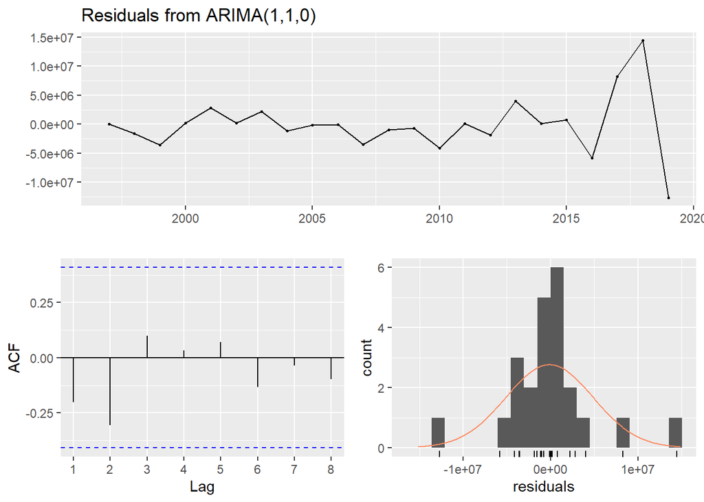

```
##
##  Ljung-Box test
##
## data:  Residuals from ARIMA(1,1,0)
## Q* = 4.7243, df = 3, p-value = 0.1931
##
## Model df: 3.   Total lags used: 6
```

```r
soybeans_mod <- arima(x=soybeans_ts[,"tons"], order=c(1,1,0), xreg=soybeans_ts[,-1])
checkresiduals(soybeans_mod)
```

```r
xreg_soybeans <- covariates[24:34, c(2,5)]
#soybeans_fc <- forecast(soybeans_mod, xreg=xreg_soybeans)
```

*Soybean Meal:*

```r
exports %>% filter(product=="soybean_meal") %>% count(country, wt=tons, sort=TRUE) %>% head(n=5)
```

```
## # A tibble: 5 x 2
##   country             n
##   <chr>           <dbl>
## 1 Netherlands 71439005.
## 2 France      47988906.
## 3 Germany     24414845.
## 4 Thailand    23024506.
## 5 South Korea 18847461.
```

```r
exports %>% filter(product=="soybean_meal", year(date)>=2015) %>% count(country, wt=tons, sort=TRUE) %>% head(n=5)
```

```
## # A tibble: 5 x 2
##   country             n
##   <chr>           <dbl>
## 1 Netherlands 13608106.
## 2 Thailand     8891496.
## 3 France       8329131.
## 4 Indonesia    8076603.
## 5 South Korea  7455673.
```

For soybean meal, the Netherlands are the most important importer, althought in the top 3 overall, Germany lost importance in the past 5 years.

```r
soybean_meal_ts <- ts(data=cbind(tons=products_fc_df$soybean_meal, price=covariates$price_soybean_meal, gdp_netherlands=covariates$gpd_netherlands, gdp_thai=covariates$gdp_thailand), start=1997, end=2019)
cor(soybean_meal_ts)
```

```
##                      tons     price gdp_netherlands  gdp_thai
## tons            1.0000000 0.5992538       0.8554769 0.8833809
## price           0.5992538 1.0000000       0.6614418 0.7741148
## gdp_netherlands 0.8554769 0.6614418       1.0000000 0.9533115
## gdp_thai        0.8833809 0.7741148       0.9533115 1.0000000
```

Contemporary correlation of soybean meal exports in tons with soybean meal prices, the Netherlands GDP and Thailand GDP are not negligeble.

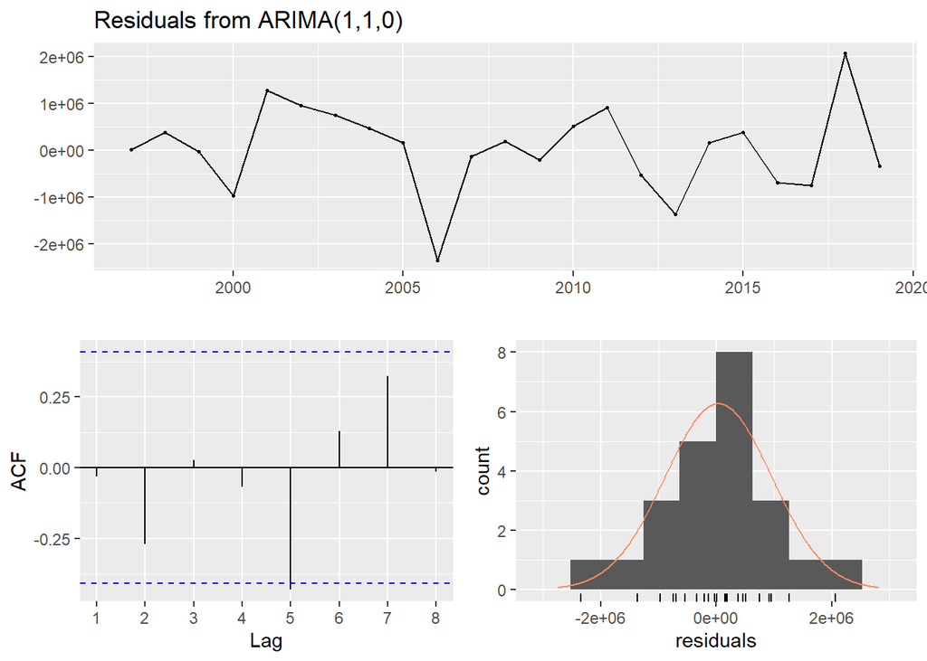

```
##
##  Ljung-Box test
##
## data:  Residuals from ARIMA(1,1,0)
## Q* = 12.54, df = 3, p-value = 0.005745
##
## Model df: 4.   Total lags used: 7
```

```r
soybean_meal_mod <- arima(x=soybean_meal_ts[,"tons"], order=c(1,1,0), xreg=soybean_meal_ts[,-1])
checkresiduals(soybean_meal_mod)
```

```r
xreg_soybean_meal = ts(covariates[24:34,c(4,7,9)], start=2020, end=2030)
colnames(xreg_soybean_meal) <- c("price","gdp_netherlands","gdp_thai")
#soybean_meal_fc <- forecast(object=soybean_meal_mod, xreg=xreg_soybean_meal, h=11)
```

I run into a problem executing the forecast command that I could not solve in time for both forecasts. Nevertheless, the fundamentals of modelling and getting the forecast were presented. The next step is to solve this problem to indeed get the forecasts.